# 1A - SET DIRECTORY AND DOWNLOAD/UNZIP DATA

```r
if (getwd() != "/Users/lylestewart/Desktop"){setwd( "/Users/lylestewart/Desktop"
)} else{ print(" We are already in the proper directory")}

if (!file.exists("data")){dir.create("data")} else{print("Directory Already Exists")}
```

```
## [1] "Directory Already Exists"
```

```r
fileUrl <- "https://d396qusza40orc.cloudfront.net/repdata%2Fdata%2Factivity.zip"
temp <- tempfile()
download.file(fileUrl, temp, method = "curl")
activity <- unzip(temp)
activity <- read.csv(activity)
View(activity) # quick glance
dateDownloaded <- date()
```

# 1B Check class and add variables

```r
str(activity) # check variable classes
```

```
## 'data.frame':    17568 obs. of  3 variables:
##  $ steps   : int  NA NA NA NA NA NA NA NA NA NA ...
##  $ date    : Factor w/ 61 levels "2012-10-01","2012-10-02",..: 1 1 1 1 1 1 1 1 1 1 ...
##  $ interval: int  0 5 10 15 20 25 30 35 40 45 ...
```

```r
activity$day <- weekdays(as.Date(activity$date))
activity$DateTime<- as.POSIXct(activity$date, format="%Y-%m-%d")
```

# 1C Clean data for missing values

```r
cleanData <- activity[!is.na(activity$steps),]
str(cleanData)
```

```
## 'data.frame':    15264 obs. of  5 variables:
##  $ steps   : int  0 0 0 0 0 0 0 0 0 0 ...
##  $ date    : Factor w/ 61 levels "2012-10-01","2012-10-02",..: 2 2 2 2 2 2 2 2 2 2 ...
##  $ interval: int  0 5 10 15 20 25 30 35 40 45 ...
##  $ day     : chr  "Tuesday" "Tuesday" "Tuesday" "Tuesday" ...
##  $ DateTime: POSIXct, format: "2012-10-02" "2012-10-02" ...
```

# 2 What is mean total of steps taken per day

# 2A - Create subset object with total steps

```r
stepsTotal <- aggregate(activity$steps ~ activity$date, FUN=sum)
colnames(stepsTotal)<- c("Date", "Steps")
```

#2B - Calculate mean/median of steps per day

```r
paste("The Average Number of Steps Taken Per Day Was",as.integer(mean(stepsTotal$Steps)), "Steps")
```

```
## [1] "The Average Number of Steps Taken Per Day Was 10766 Steps"
```

```r
paste("The Meaian Steps Per Day Was", as.integer(median(stepsTotal$Steps)),"Steps")
```

```
## [1] "The Meaian Steps Per Day Was 10765 Steps"
```

#2C - Create histogram of steps per day

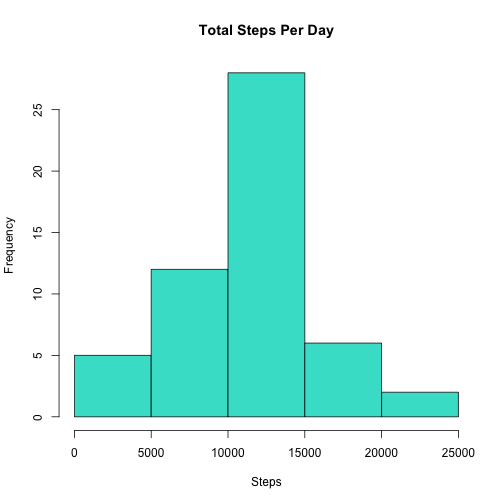

#3 What is the average daily activity pattern? #3A Load Packages and show clean data

```r
library(plyr)
library(ggplot2)
# Remember the data we cleaned from earlier
cleanData <- activity[!is.na(activity$steps),]
str(cleanData)
```

```
## 'data.frame':    15264 obs. of  5 variables:
##  $ steps   : int  0 0 0 0 0 0 0 0 0 0 ...
##  $ date    : Factor w/ 61 levels "2012-10-01","2012-10-02",..: 2 2 2 2 2 2 2 2 2 2 ...
##  $ interval: int  0 5 10 15 20 25 30 35 40 45 ...
##  $ day     : chr  "Tuesday" "Tuesday" "Tuesday" "Tuesday" ...
##  $ DateTime: POSIXct, format: "2012-10-02" "2012-10-02" ...
```

#3B Show average steps per interval through table

```r
intervalTable <- ddply(cleanData, .(interval), summarize, Avg = mean(steps))
str(intervalTable)
```

```
## 'data.frame':    288 obs. of  2 variables:
##  $ interval: int  0 5 10 15 20 25 30 35 40 45 ...
##  $ Avg     : num  1.717 0.3396 0.1321 0.1509 0.0755 ...
```

#3C Create the required line plot of average steps per interval data

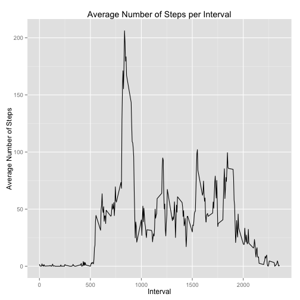

#3D Which 5-minute interval, on average across all the days in the dataset, contains the maximum number of steps?

```r
paste("The Max Number Of Steps In A 5 Minute Interval Was", as.integer( max(intervalTable$Avg)), "Steps")
```

```
## [1] "The Max Number Of Steps In A 5 Minute Interval Was 206 Steps"
```

```r
paste("The 5 Minute Interval That Contained The Max Average Number of Steps Was The", intervalTable[intervalTable$Avg==maxSteps,1], "Interval" )
```

```
## [1] "The 5 Minute Interval That Contained The Max Average Number of Steps Was The 835 Interval"
```

#4 Inputting The Missing Values

```r
#4A Calculate and report the total number of missing values in the dataset (i.e. the total number of rows with NAs)
sum(is.na(activity$steps))
```

```
## [1] 2304
```

#4B Devise a strategy for filling in all of the missing values in the dataset. - We sub NAs with the Average whereas to minimize effect on original data.

```r
avgTable <- ddply(cleanData, .(interval, day), summarize, Avg = mean(steps)) # avg steps per weekday/ interval

nadata<- activity[is.na(activity$steps),] # all NAs included for later substitution

NA.AVG.Activity<-merge(nadata, avgTable, by=c("interval", "day")) # merge the NA and non NA data

NA.AVG.Activity2 <- NA.AVG.Activity[,c(6,4,1,2,5)] # reorder new data in same format as the clean
colnames(NA.AVG.Activity2) <- c("steps", "date", "interval", "day", "DateTime")

mergeData <- rbind(cleanData, NA.AVG.Activity2)#merge averages
```

#4C Histogram - Make a histogram of the total number of steps taken each day and Calculate and report the mean and median total number of steps taken per day. Do these values differ from the estimates from the first part of the assignment? What is the impact of imputing missing data on the estimates of the total daily number of steps?

```r
stepsTotal2 <- aggregate(mergeData$steps ~ mergeData$date, FUN=sum ) # devise sum of steps per data to compare with orig step.
colnames(stepsTotal2)<- c("Date", "Steps")

paste("The Mean Number of Steps With NA Data Accounted For Is", as.integer(mean(stepsTotal2$Steps)),"Steps")
```

```
## [1] "The Mean Number of Steps With NA Data Accounted For Is 10821 Steps"
```

```r
paste("The Median Of Steps With NA Data Accounted For Is", as.integer(median(stepsTotal2$Steps)), "Steps")
```

```
## [1] "The Median Of Steps With NA Data Accounted For Is 11015 Steps"
```

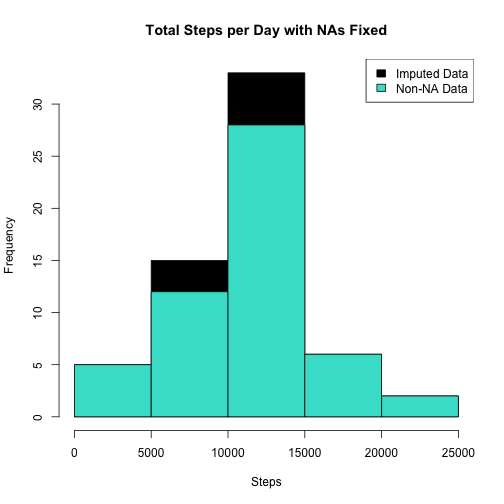

```r
#New Median = 11015, Old Median = 10765 steps.
#New Mean = 10821 steps, Old Mean = 10766 steps.
#Distribution Shape has not Changed at all.
```

#5 Are there differences in activity patterns between weekdays and weekends? - Make Interval Time Series

```r
mergeData$DayCategory <- ifelse(mergeData$day %in% c("Saturday", "Sunday"), "Weekend", "Weekday")
library(lattice)

intervalTable2 <- ddply(mergeData, .(interval, DayCategory), summarize, Avg = mean(steps))
```

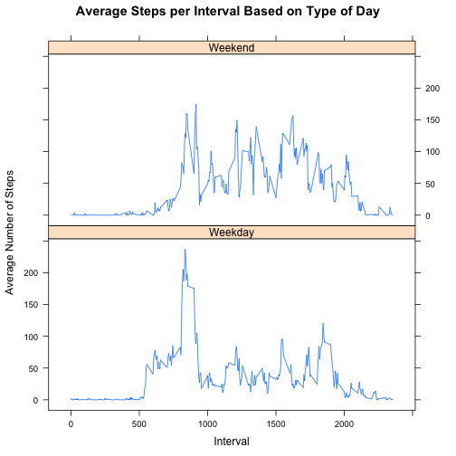

```r
# Finding : Overall the step data varies between weekday and weekend. Various reasons could be the cause for this.
```